# Leefbaarheid en eenzaamheid in Amsterdam Zuid en Zuidoost

2026-11-26

# Voorbereiding

Open eerst het project door te dubbelklikken op `eenzaamheid_leefbaarheid.Rproj`. Voer daarna de blokken code één voor één uit met het groene pijltje.

```r
library(tidyverse)
library(readxl)
```

## Staan de bestanden op de goede plek?

```r
getwd()
```

```
## [1] "/Users/alidervis/Documents/GitHub/ACVA-eenzaamheid"
```

```r
list.files("data")
```

```
##  [1] "50150NED_TabelIndeling_20261111131831.csv"
##  [2] "50150NED_UntypedDataSet_20261119121801.csv"
##  [3] "kittens 1.csv"
##  [4] "kittens_puntkomma.csv"
##  [5] "kittens.csv"
##  [6] "kittens.rds"
##  [7] "kittens.xlsx"
##  [8] "kwb2024.xlsx"
##  [9] "leefbaarometer_buurten_2002_2024.csv"
## [10] "midwest.csv"
## [11] "open-data-leefbaarometer-meting-2024.zip"
## [12] "Toetsen_t_en_z.Rmd"
```

Zie je hier je datasets staan? Dan kan R ze vinden.

# Deel 1 - De data

## 1.1 Eenzaamheid inladen

**Bron:** CBS StatLine, tabel 50150NED “Gezondheid per wijk en buurt; 2012/2016/2020/2022/2024 (indeling 2024)”. Gezondheidsmonitor Volwassenen en Ouderen 2024, GGD’en/CBS/RIVM, bewerking volgens de SMAP-methodiek van RIVM. Gedownload op 19 november 2026.

Het bestand gebruikt een puntkomma tussen de kolommen, maar een **punt** als decimaalteken (47.2). Daarom geen `read_csv2()`, want die leest 47.2 als 472. We gebruiken `read_delim()` en zeggen zelf welk teken tussen de kolommen staat. Alles lezen we eerst als tekst (`"c"`), omdat er spaties rond de waarden staan.

```r
eenzaamheid_ruw <- read_delim(
  "data/50150NED_UntypedDataSet_20261119121801.csv",
  delim = ";",
  col_types = cols(.default = "c")
)
```

De spaties weghalen met `trimws()`, in alle kolommen tegelijk:

```r
eenzaamheid_ruw <- eenzaamheid_ruw |>
  mutate(across(everything(), trimws))

glimpse(eenzaamheid_ruw)
```

```
## Rows: 54,930
## Columns: 9
## $ ID              <chr> "4", "9", "14", "19", "24", "29", "34", "39", "44", "4…
## $ Leeftijd        <chr> "20300", "20300", "20300", "20300", "20300", "20300", …
## $ Marges          <chr> "MW00000", "MW00000", "MW00000", "MW00000", "MW00000",…
## $ WijkenEnBuurten <chr> "NL01", "GM1680", "WK168000", "BU16800000", "BU1680000…
## $ Perioden        <chr> "2024JJ00", "2024JJ00", "2024JJ00", "2024JJ00", "2024J…
## $ Gemeentenaam_1  <chr> "Nederland", "Aa en Hunze", "Aa en Hunze", "Aa en Hunz…
## $ SoortRegio_2    <chr> "Land", "Gemeente", "Wijk", "Buurt", "Buurt", "Wijk", …
## $ Codering_3      <chr> "NL01", "GM1680", "WK168000", "BU16800000", "BU1680000…
## $ Eenzaam_25      <chr> "47.2", "43.2", "41.6", "41.7", "39.3", "41.4", "41.2"…
```

## 1.2 Wat zit erin?

```r
count(eenzaamheid_ruw, SoortRegio_2)
```

```
## # A tibble: 4 × 2
##   SoortRegio_2     n
##   <chr>        <int>
## 1 Buurt        43722
## 2 Gemeente      1026
## 3 Land             3
## 4 Wijk         10179
```

```r
count(eenzaamheid_ruw, Leeftijd)
```

```
## # A tibble: 3 × 2
##   Leeftijd     n
##   <chr>    <int>
## 1 20300    18310
## 2 53115    18310
## 3 80200    18310
```

Het bestand bevat heel Nederland: land, gemeenten, wijken en buurten, en drie leeftijdsgroepen. Elke buurt staat er dus drie keer in. Net als bij de kittens (één rij per provincie per jaar) kiezen we eerst wat één waarneming is.

## 1.3 Alleen buurten in Zuid en Zuidoost

Amsterdam codeert buurten met een letter voor het stadsdeel, op de 7e plek van de code: `BU0363`**K**`A01`. **K** = Zuid, **T** = Zuidoost.

```r
buurten <- eenzaamheid_ruw |>
  filter(
    Gemeentenaam_1 == "Amsterdam",
    SoortRegio_2   == "Buurt",
    Leeftijd       == "20300"          # 18 jaar of ouder: nog checken in StatLine
  ) |>
  mutate(
    letter    = substr(Codering_3, 7, 7),
    eenzaam   = as.numeric(na_if(Eenzaam_25, "."))   # een punt betekent: geen cijfer
  ) |>
  filter(letter %in% c("K", "T")) |>
  mutate(stadsdeel = if_else(letter == "K", "Zuid", "Zuidoost")) |>
  select(buurtcode = Codering_3, stadsdeel, eenzaam)

buurten
```

```
## # A tibble: 122 × 3
##    buurtcode  stadsdeel eenzaam
##    <chr>      <chr>       <dbl>
##  1 BU0363KA01 Zuid         48
##  2 BU0363KA02 Zuid         46.1
##  3 BU0363KA03 Zuid         47.6
##  4 BU0363KA04 Zuid         46.9
##  5 BU0363KA05 Zuid         48
##  6 BU0363KA06 Zuid         66.7
##  7 BU0363KB01 Zuid         49.9
##  8 BU0363KB02 Zuid         53.9
##  9 BU0363KC01 Zuid         NA
## 10 BU0363KC02 Zuid         41.5
## # ℹ 112 more rows
```

## 1.4 Ontbreken er waarden?

```r
buurten |>
  group_by(stadsdeel) |>
  summarise(
    buurten       = n(),
    zonder_cijfer = sum(is.na(eenzaam))
  )
```

```
## # A tibble: 2 × 3
##   stadsdeel buurten zonder_cijfer
##   <chr>       <int>         <int>
## 1 Zuid           76            10
## 2 Zuidoost       46             8
```

Buurten zonder cijfer hebben te weinig inwoners of respondenten. Die vallen af, en dat schrijven we op bij de **populatie**.

## 1.5 Leefbaarheid inladen

**Bron:** Leefbaarometer 3.0, meting 2024, open data (ministerie van BZK), leefbaarometer.nl. Gedownload op 25 november 2026. Uit de zip hebben we alleen het bestand `Leefbaarometer-scores buurten 2002-2024.csv` gehaald en opgeslagen als `data/leefbaarometer_buurten_2002_2024.csv`.

Dit is een gewoon csv-bestand: komma’s tussen de kolommen, punt als decimaalteken. Dus gewoon `read_csv()`.

```r
leefbaarheid_ruw <- read_csv("data/leefbaarometer_buurten_2002_2024.csv")
glimpse(leefbaarheid_ruw)
```

```
## Rows: 125,105
## Columns: 10
## $ bu_code <chr> "BU00140000", "BU00140000", "BU00140000", "BU00140000", "BU001…
## $ bu_naam <chr> "Binnenstad-Noord", "Binnenstad-Noord", "Binnenstad-Noord", "B…
## $ jaar    <dbl> 2002, 2008, 2012, 2014, 2016, 2018, 2020, 2022, 2024, 2002, 20…
## $ lbm     <dbl> 4.134895, 4.186980, 4.217256, 4.219229, 4.284220, 4.296013, 4.…
## $ afw     <dbl> 0.032629792, 0.084715580, 0.114991630, 0.116964109, 0.18195530…
## $ fys     <dbl> NA, NA, NA, 0.039578524, NA, 0.040776837, 0.043572835, 0.04050…
## $ onv     <dbl> NA, NA, NA, -0.14349618, NA, -0.10128200, -0.08225781, -0.0845…
## $ soc     <dbl> NA, NA, NA, -0.03341563, NA, -0.03088536, -0.03183636, -0.0380…
## $ vrz     <dbl> NA, NA, NA, 0.2362346, NA, 0.2747075, 0.3000654, 0.3124377, 0.…
## $ won     <dbl> NA, NA, NA, 0.0180627618, NA, 0.0104310267, 0.0094752385, 0.01…
```

Wat betekenen de kolommen?

| Kolom | Betekenis |
| --- | --- |
| `bu_code` | buurtcode, dezelfde codes als in het eenzaamheidsbestand |
| `jaar` | meetjaar (2002 tot en met 2024) |
| `lbm` | de totale leefbaarheidsscore: hoe hoger, hoe leefbaarder |
| `fys`, `onv`, `soc`, `vrz`, `won` | de vijf dimensies: fysieke omgeving, overlast en onveiligheid, sociale samenhang, voorzieningen, woningvoorraad |

Elke buurt staat er meerdere keren in, één rij per meetjaar. Wij nemen alleen 2024, het jaar van de eenzaamheidscijfers.

```r
leefbaarheid <- leefbaarheid_ruw |>
  filter(jaar == 2024) |>
  select(buurtcode = bu_code, buurtnaam = bu_naam, lbm, fys, onv, soc, vrz, won)
```

## 1.6 De twee bestanden koppelen

Beide bestanden hebben een buurtcode. Met `left_join()` plakken we de leefbaarheid achter elke buurt uit ons eenzaamheidsbestand.

```r
analyse_data <- buurten |>
  left_join(leefbaarheid, by = "buurtcode")

analyse_data
```

```
## # A tibble: 122 × 10
##    buurtcode  stadsdeel eenzaam buurtnaam    lbm      fys     onv     soc    vrz
##    <chr>      <chr>       <dbl> <chr>      <dbl>    <dbl>   <dbl>   <dbl>  <dbl>
##  1 BU0363KA01 Zuid         48   Westlandg…  4.30 -0.0204  -0.0461 -0.104   0.417
##  2 BU0363KA02 Zuid         46.1 Surinamep…  4.41 -0.0104  -0.0407 -0.0850  0.477
##  3 BU0363KA03 Zuid         47.6 Legmeerpl…  4.34 -0.0114  -0.0747 -0.110   0.452
##  4 BU0363KA04 Zuid         46.9 Aalsmeerw…  4.25 -0.0206  -0.0693 -0.0984  0.398
##  5 BU0363KA05 Zuid         48   Aalsmeerw…  4.28 -0.0209  -0.0662 -0.0955  0.400
##  6 BU0363KA06 Zuid         66.7 Bedrijven…  4.45 -0.0942  -0.0343  0.125   0.285
##  7 BU0363KB01 Zuid         49.9 Schinkelb…  4.40 -0.0224  -0.0988 -0.104   0.492
##  8 BU0363KB02 Zuid         53.9 Schinkelb…  4.36 -0.0239  -0.113  -0.115   0.472
##  9 BU0363KC01 Zuid         NA   <NA>       NA    NA       NA      NA      NA
## 10 BU0363KC02 Zuid         41.5 Willemspa…  4.60 -0.00993 -0.0284 -0.0617  0.502
## # ℹ 112 more rows
## # ℹ 1 more variable: won <dbl>
```

Hoeveel buurten hebben allebei de cijfers?

```r
analyse_data |>
  group_by(stadsdeel) |>
  summarise(
    buurten             = n(),
    zonder_eenzaamheid  = sum(is.na(eenzaam)),
    zonder_leefbaarheid = sum(is.na(lbm)),
    allebei             = sum(!is.na(eenzaam) & !is.na(lbm))
  )
```

```
## # A tibble: 2 × 5
##   stadsdeel buurten zonder_eenzaamheid zonder_leefbaarheid allebei
##   <chr>       <int>              <int>               <int>   <int>
## 1 Zuid           76                 10                   2      66
## 2 Zuidoost       46                  8                   4      38
```

Alleen buurten met allebei de cijfers gaan mee in de analyse.

```r
analyse_compleet <- analyse_data |>
  filter(!is.na(eenzaam), !is.na(lbm))

nrow(analyse_compleet)
```

```
## [1] 104
```

## 1.7 Een eerste blik

Elke stip is één buurt.

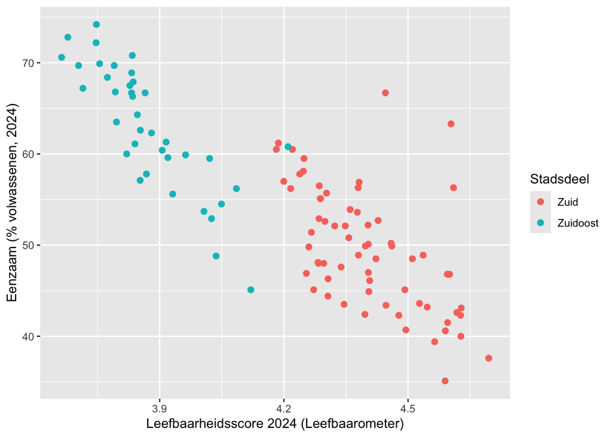

```r
ggplot(analyse_compleet, aes(x = lbm, y = eenzaam, colour = stadsdeel)) +
  geom_point(size = 2) +
  labs(x = "Leefbaarheidsscore 2024 (Leefbaarometer)",
       y = "Eenzaam (% volwassenen, 2024)",
       colour = "Stadsdeel")
```

## 1.8 Controlevariabele: WOZ-waarde

**Bron:** CBS, Kerncijfers wijken en buurten 2024 (StatLine-tabel 85984NED), Excelbestand van cbs.nl. Gedownload op 25 november 2026, opgeslagen als `data/kwb2024.xlsx`.

Leefbare buurten zijn vaak ook duurdere buurten. Met de WOZ-waarde erbij kunnen we later (H13) kijken of leefbaarheid samenhangt met eenzaamheid **bij gelijke WOZ-waarde**.

Een Excelbestand lees je in met `read_excel()`.

```r
kwb_ruw <- read_excel("data/kwb2024.xlsx")
```

Het bestand heeft meer dan 100 kolommen. De WOZ-waarde staat in `g_wozbag`, in duizenden euro’s. Een punt betekent: geen cijfer.

```r
woz <- kwb_ruw |>
  filter(recs == "Buurt", gm_naam == "Amsterdam") |>
  mutate(woz = as.numeric(na_if(as.character(g_wozbag), "."))) |>
  select(buurtcode = gwb_code, woz)
```

Koppelen aan de rest, en opnieuw alleen de buurten houden waar alles bekend is:

```r
analyse_data <- analyse_data |>
  left_join(woz, by = "buurtcode")

analyse_compleet <- analyse_data |>
  filter(!is.na(eenzaam), !is.na(lbm), !is.na(woz))

count(analyse_compleet, stadsdeel)
```

```
## # A tibble: 2 × 2
##   stadsdeel     n
##   <chr>     <int>
## 1 Zuid         64
## 2 Zuidoost     38
```

Hangt de WOZ-waarde ook samen met eenzaamheid?

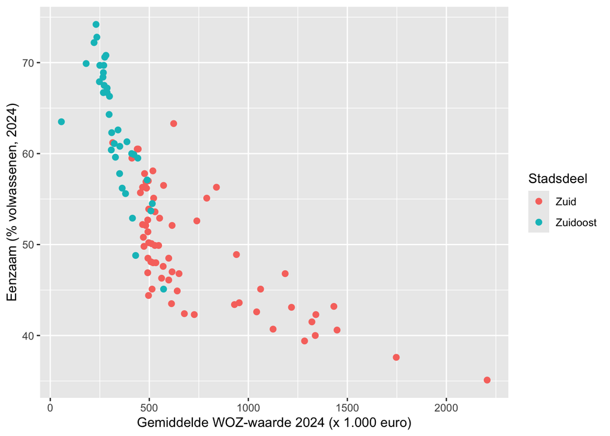

```r
ggplot(analyse_compleet, aes(x = woz, y = eenzaam, colour = stadsdeel)) +
  geom_point(size = 2) +
  labs(x = "Gemiddelde WOZ-waarde 2024 (x 1.000 euro)",
       y = "Eenzaam (% volwassenen, 2024)",
       colour = "Stadsdeel")
```

# Deel 2 - Methoden

## 2.2 Variabelen

- **Afhankelijke variabele:** `eenzaam`, percentage eenzame volwassenen per buurt (Gezondheidsmonitor 2024)
- **Onafhankelijke variabele(n):** `lbm`, leefbaarheidsscore per buurt (Leefbaarometer 2024)
- **Controlevariabele:** `woz`, gemiddelde WOZ-waarde van woningen per buurt (CBS 2024)

## 2.4 Procedure

Stap voor stap hoe we van de gedownloade bestanden bij de analysedataset kwamen. Deze Rmd ís die procedure.

# Deel 3 - Resultaten

## 3.1 Beschrijvende statistiek

## 3.2 Aannames

## 3.3 Toetsende statistiek